# Logistic Regression

Nayan Saikia

February 29, 2016

This is a logistic regression exercise to predict survivability of a passenger in titanic. We first load the titanic dataset and remove the first attribute (passenger ID) as it is meaningless.

```r
titanic.df <- read.csv("/home/awaz/Documents/UISCourses/DataScience/train.csv")
#remove passenger ID
titanic.df <- titanic.df[-1]
```

Intuitively, we can say that name, ticket number, cabin are not relevant. So, we will exclude these from our dataframe.

```r
exclude.col <- c("Name","Ticket","Cabin")
titanic.mod <- titanic.df[,-which(names(titanic.df) %in% exclude.col)]
```

Next, let us check if there any null values in any of the remaining variables

```r
sum(is.na(titanic.mod$Survived))
```

```
## [1] 0
```

```r
sum(is.na(titanic.mod$Pclass))
```

```
## [1] 0
```

```r
sum(is.na(titanic.mod$Sex))
```

```
## [1] 0
```

```r
sum(is.na(titanic.mod$Age))
```

```
## [1] 177
```

```r
sum(is.na(titanic.mod$SibSp))
```

```
## [1] 0
```

```r
sum(is.na(titanic.mod$Parch))
```

```
## [1] 0
```

```r
sum(is.na(titanic.mod$Fare))
```

```
## [1] 0
```

```r
sum(is.na(titanic.mod$Embarked))
```

```
## [1] 0
```

Well, we are missing age on number of rows. There are various ways to resolve this. We can discard the rows where age is missing, we can replace the missing values with the mean age, or we can use a model to predict age. The last option is the best one and so we will try that. For this exercise, we will use a ridge linear model to predict age and will a function from the ‘ridge’ library, which is deprecated now. Reason for choosing ‘ridge’ over ‘MASS’ is the ease of determining the regularization parameter. Using ‘ridge’ allows us to provide lamda=“automatic”, which saves a lot of time. Before we go about predicting age, we will need to re-download the dataset. This is because the first time we download, all string values got automatically set as factors. For linear regression to work, we want them to stay as strings or characters so we can convert them to some numeric value. In our case, the only independent variable that we want to do this conversion is ‘sex’. In the next section, we load the dataset, convert male to 0 and female to 1, and remove attributes/columns that are of no interest to us.

```r
titan.lr.df <- read.csv("/home/awaz/Documents/UISCourses/DataScience/train.csv", stringsAsFactors = FALSE)
#conver male to 0 and female to 1
titan.lr.df$Sex[titan.lr.df$Sex == "male"] <- 0
titan.lr.df$Sex[titan.lr.df$Sex == "female"] <- 1
#remove unwanted columns
titan.lr.df <- titan.lr.df[,-which(names(titan.lr.df) %in% c("Name","Ticket","Cabin","Embarked"))]
#could have removed passenger id above, but removing it here
titan.lr.df <- titan.lr.df[-1]
#convert the column 'sex' from char to integer
titan.lr.df <- transform(titan.lr.df,Sex = as.integer(Sex))
```

Next we will split the new dataframe into test and train. Train will contain all rows with known age, while test will have rows with missing ages. We also create a train and test set without the dependent variable ‘age’

```r
#create train and test set
titan.age.train <- na.omit(titan.lr.df, cols = "Age")
titan.age.ped <- subset(titan.lr.df, is.na(titan.lr.df$Age))
#remove dependent variable
titan.age.train1 <- titan.age.train[,-which(names(titan.age.train) %in% c("Age"))]
titan.age.ped1 <- titan.age.ped[,-which(names(titan.age.ped) %in% c("Age"))]
```

Let us now predict age using ‘ridgelinear’. Once we get predicted values, we will repopulate any missing values in our dataframe using the predict values.

```r
#ridge linear using ridgelm
library(ridge)
lmridge.model <- linearRidge(titan.age.train$Age~.,data=titan.age.train1,lamda="automatic")
#predict age for the missing ones
titan.age.predict <- predict(lmridge.model,titan.age.ped1)
#round the ages to the nearest integer
titan.age.predict <- round(titan.age.predict, digits = 0)
#replace the age in the test set with the predicted values
titan.age.ped$Age <- titan.age.predict
#combine test and train set so we have a full dataframe again
titan.age.determined <- rbind(titan.age.train,titan.age.ped)
#now replace the missing ages in the original dataframe
titanic.mod$Age <- titan.age.determined$Age
```

We now have a dataframe with no missing ages. We will now split again the dataframe to test and train. We will keep about 1/3 rows in test.

```r
#split test and train
index <- 1:nrow(titanic.df)
testindex <- sample(index,trunc(length(index)/3))
titanic.test <- titanic.mod[testindex,]
titanic.train <- titanic.mod[-testindex,]
#save and then remove the dependant variable from test set
titanic.test.label <- titanic.test[,1]
titanic.test <- titanic.test[,-1]
```

We will now use funciton ‘glm’ to build a logistic regression model and predict the labels from our test set

```r
titanic.model <- glm(titanic.train$Survived~.,family = binomial(link = 'logit'),data = titanic.train)
summary(titanic.model)
```

```
##
## Call:
## glm(formula = titanic.train$Survived ~ ., family = binomial(link = "logit"),
##     data = titanic.train)
##
## Deviance Residuals:
##     Min       1Q   Median       3Q      Max
## -2.0348  -0.6567  -0.4163   0.6653   2.3642
##
## Coefficients:
##               Estimate Std. Error z value Pr(>|z|)
## (Intercept)  14.657074 535.411310   0.027   0.9782
## Pclass       -1.003390   0.162413  -6.178 6.49e-10 ***
## Sexmale      -2.749430   0.242833 -11.322  < 2e-16 ***
## Age          -0.005195   0.007935  -0.655   0.5126
## SibSp        -0.310242   0.140675  -2.205   0.0274 *
## Parch         0.007883   0.129845   0.061   0.9516
## Fare          0.000788   0.002802   0.281   0.7786
## EmbarkedC   -10.713196 535.411273  -0.020   0.9840
## EmbarkedQ   -10.864432 535.411371  -0.020   0.9838
## EmbarkedS   -11.127657 535.411257  -0.021   0.9834
## ---
## Signif. codes:  0 '***' 0.001 '**' 0.01 '*' 0.05 '.' 0.1 ' ' 1
##
## (Dispersion parameter for binomial family taken to be 1)
##
##     Null deviance: 791.10  on 593  degrees of freedom
## Residual deviance: 532.56  on 584  degrees of freedom
## AIC: 552.56
##
## Number of Fisher Scoring iterations: 12
```

```r
#predict
predicted.results <- predict(titanic.model,newdata = titanic.test,type = 'response')
```

Next we measure performance using RORC package and determine AUC

```r
library(ROCR)
pred <- prediction(predicted.results,titanic.test.label)
perf <- performance(pred, measure = "tpr", x.measure = "fpr")
```

Here is the plot looks like:

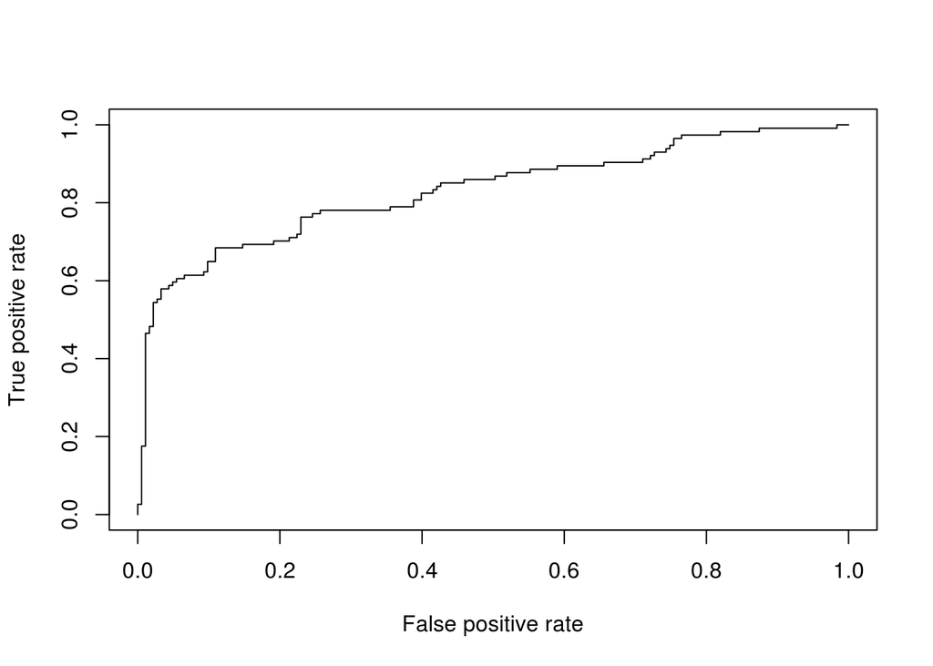

And finally, AUC!

```r
auc <- performance(pred,measure = "auc")
auc <- auc@y.values[[1]]
```

The AUC value is 0.830697